# HousePricesRegression

### House prices regression

The following is an analysis of the house prices dataset available at: 'https://www.kaggle.com/harlfoxem/housesalesprediction'  
The structure of the notebook is the following:

1. Exploration
2. Calculation of return on houses that appear multiple times in the database
3. Exploring the target variable (price) and scaling outliers to the 99th percentile
4. Fitting a simple linear model
5. Creating new variables and testing for significance
6. Correlation analysis and a note on multicollinearity
7. Comparing different model outputs

```python
from scipy import stats
import statsmodels.stats.weightstats as ws
import scipy.stats as ss
import pandas as pd
import datetime as dt
import matplotlib.pyplot as plt
import seaborn as sns
from sklearn.ensemble import RandomForestRegressor
from sklearn.linear_model import LinearRegression
from sklearn.linear_model import Ridge
from sklearn.model_selection import train_test_split
from sklearn.metrics import r2_score,mean_absolute_error, mean_squared_error
import scipy.stats as stats
from sklearn.model_selection import cross_validate, KFold
```

```python
df = pd.read_csv('data/kc_house_data.csv', encoding = "utf-8")
pd.set_option('display.max_columns', df.shape[1])
df.head()

DATASET_URL = 'https://www.kaggle.com/harlfoxem/housesalesprediction'
```

**1. Exploration**

```python
df.info()
```

```
<class 'pandas.core.frame.DataFrame'>
RangeIndex: 21613 entries, 0 to 21612
Data columns (total 21 columns):
 #   Column         Non-Null Count  Dtype
---  ------         --------------  -----
 0   id             21613 non-null  int64
 1   date           21613 non-null  object
 2   price          21613 non-null  float64
 3   bedrooms       21613 non-null  int64
 4   bathrooms      21613 non-null  float64
 5   sqft_living    21613 non-null  int64
 6   sqft_lot       21613 non-null  int64
 7   floors         21613 non-null  float64
 8   waterfront     21613 non-null  int64
 9   view           21613 non-null  int64
 10  condition      21613 non-null  int64
 11  grade          21613 non-null  int64
 12  sqft_above     21613 non-null  int64
 13  sqft_basement  21613 non-null  int64
 14  yr_built       21613 non-null  int64
 15  yr_renovated   21613 non-null  int64
 16  zipcode        21613 non-null  int64
 17  lat            21613 non-null  float64
 18  long           21613 non-null  float64
 19  sqft_living15  21613 non-null  int64
 20  sqft_lot15     21613 non-null  int64
dtypes: float64(5), int64(15), object(1)
memory usage: 3.5+ MB
```

```python
df.head()
```

|  | id | date | price | bedrooms | bathrooms | sqft_living | sqft_lot | floors | waterfront | view | condition | grade | sqft_above | sqft_basement | yr_built | yr_renovated | zipcode | lat | long | sqft_living15 | sqft_lot15 |
| --- | --- | --- | --- | --- | --- | --- | --- | --- | --- | --- | --- | --- | --- | --- | --- | --- | --- | --- | --- | --- | --- |
| 0 | 7129300520 | 20141013T000000 | 221900.0 | 3 | 1.00 | 1180 | 5650 | 1.0 | 0 | 0 | 3 | 7 | 1180 | 0 | 1955 | 0 | 98178 | 47.5112 | -122.257 | 1340 | 5650 |
| 1 | 6414100192 | 20141209T000000 | 538000.0 | 3 | 2.25 | 2570 | 7242 | 2.0 | 0 | 0 | 3 | 7 | 2170 | 400 | 1951 | 1991 | 98125 | 47.7210 | -122.319 | 1690 | 7639 |
| 2 | 5631500400 | 20150225T000000 | 180000.0 | 2 | 1.00 | 770 | 10000 | 1.0 | 0 | 0 | 3 | 6 | 770 | 0 | 1933 | 0 | 98028 | 47.7379 | -122.233 | 2720 | 8062 |
| 3 | 2487200875 | 20141209T000000 | 604000.0 | 4 | 3.00 | 1960 | 5000 | 1.0 | 0 | 0 | 5 | 7 | 1050 | 910 | 1965 | 0 | 98136 | 47.5208 | -122.393 | 1360 | 5000 |
| 4 | 1954400510 | 20150218T000000 | 510000.0 | 3 | 2.00 | 1680 | 8080 | 1.0 | 0 | 0 | 3 | 8 | 1680 | 0 | 1987 | 0 | 98074 | 47.6168 | -122.045 | 1800 | 7503 |

```python
df.isnull().sum()
```

```
id               0
date             0
price            0
bedrooms         0
bathrooms        0
sqft_living      0
sqft_lot         0
floors           0
waterfront       0
view             0
condition        0
grade            0
sqft_above       0
sqft_basement    0
yr_built         0
yr_renovated     0
zipcode          0
lat              0
long             0
sqft_living15    0
sqft_lot15       0
dtype: int64
```

no missing values, yay!

```python
df['id'].value_counts()
```

```
795000620     3
2206700215    2
643300040     2
3333002450    2
1995200200    2
             ..
3420069065    1
7812801125    1
4364700875    1
3021059276    1
1777500160    1
Name: id, Length: 21436, dtype: int64
```

there are id's which appear multiple times, let's check them out.

**2. Calculation of return on houses that appear multiple times in the database**

let's calculate return on those where we have multiple items of the same id.

```python
idcount = df[['id', 'date']].groupby(['id']).count()
double_ids = idcount.loc[idcount['date']>1].reset_index()['id'].tolist()
```

```python
newdf = df.loc[df['id'].isin(double_ids)]
```

```python
newdf.shape
```

```
(353, 21)
```

```python
#%% calculate return on houses
returndf = newdf[['id', 'price']].groupby(['id']).agg(['min','max']).reset_index(drop = False)
#%%
```

```python
returndf.shape
#%%
```

```
(176, 3)
```

```python
returndf.head(15)
#%%
```

|  | id | price min | price max |
| --- | --- | --- | --- |
| 0 | 1000102 | 280000.0 | 300000.0 |
| 1 | 7200179 | 150000.0 | 175000.0 |
| 2 | 109200390 | 245000.0 | 250000.0 |
| 3 | 123039336 | 148000.0 | 244900.0 |
| 4 | 251300110 | 225000.0 | 358000.0 |
| 5 | 302000375 | 169100.0 | 250000.0 |
| 6 | 324000530 | 201500.0 | 459000.0 |
| 7 | 526059224 | 260000.0 | 470000.0 |
| 8 | 641900050 | 335000.0 | 499950.0 |
| 9 | 643300040 | 481000.0 | 719521.0 |
| 10 | 705730280 | 325000.0 | 335000.0 |
| 11 | 722039087 | 220500.0 | 329000.0 |
| 12 | 723049156 | 149000.0 | 284700.0 |
| 13 | 726049190 | 287500.0 | 431000.0 |
| 14 | 795000620 | 115000.0 | 157000.0 |

```python
returndf['returnperc']=returndf.apply(lambda x: (x['price']['max'] -
                          x['price']['min'])/x['price']['min'], axis=1)
```

```python
#%%
returndf['returnperc'].mean()
```

```
0.5694610560757339
```

WHAT??? 57% return in 1 year on average? that is insane.

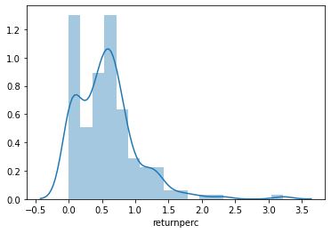

```python
sns.distplot(returndf['returnperc'])
```

for some code golf to see what was the return

```python
highreturn = 324000530
```

```python
(df[df['id'] == highreturn]['price'].max() - df[df['id'] == highreturn]
 ['price'].min()) / df[df['id'] == highreturn]['price'].min()
```

```
1.2779156327543424
```

```python
df.loc[df['id'] == highreturn]
```

|  | id | date | price | bedrooms | bathrooms | sqft_living | sqft_lot | floors | waterfront | view | condition | grade | sqft_above | sqft_basement | yr_built | yr_renovated | zipcode | lat | long | sqft_living15 | sqft_lot15 |
| --- | --- | --- | --- | --- | --- | --- | --- | --- | --- | --- | --- | --- | --- | --- | --- | --- | --- | --- | --- | --- | --- |
| 14855 | 324000530 | 20140708T000000 | 201500.0 | 3 | 1.0 | 1320 | 5000 | 1.5 | 0 | 0 | 3 | 7 | 1320 | 0 | 1912 | 0 | 98116 | 47.5711 | -122.386 | 1320 | 4179 |
| 14856 | 324000530 | 20150323T000000 | 459000.0 | 3 | 1.0 | 1320 | 5000 | 1.5 | 0 | 0 | 3 | 7 | 1320 | 0 | 1912 | 0 | 98116 | 47.5711 | -122.386 | 1320 | 4179 |

with these in the picture, it will be really difficult to model the data.

```python
df.drop('id', axis = 1, inplace=True)
```

```python
df['date'] = pd.to_datetime(df['date'])
df['year'] = df['date'].dt.year
df['month'] = df['date'].dt.month
df['day'] = df['date'].dt.day
df.drop('date', inplace=True, axis = 1)
```

**3. Exploring the target variable (price) and scaling outliers to the 99th percentile**

```python
df['price'].describe()
```

```
count    2.161300e+04
mean     5.400881e+05
std      3.671272e+05
min      7.500000e+04
25%      3.219500e+05
50%      4.500000e+05
75%      6.450000e+05
max      7.700000e+06
Name: price, dtype: float64
```

there is an order of magnitude of difference between the 75th percentile and the max

let's plot what the house prices look like

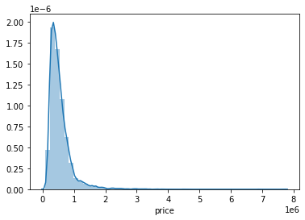

```python
sns.distplot(df['price']);
```

is there some sort of yearly fluctuation in the data?

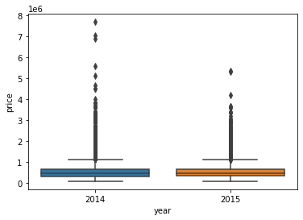

```python
target = 'price'
sns.boxplot(data=df, x='year', y=target)
```

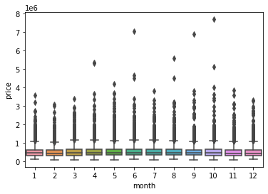

```python
sns.boxplot(data=df, x='month', y=target)
```

what these two boxplots show is that there is no significant difference in years or months just by eyeballing the data.

have a look at the different percentiles for the data:

```python
df['price'].quantile([0.9,0.95,0.96,0.97,0.98,0.99,1])
```

```
0.90     887000.0
0.95    1156480.0
0.96    1259040.0
0.97    1388000.0
0.98    1600000.0
0.99    1964400.0
1.00    7700000.0
Name: price, dtype: float64
```

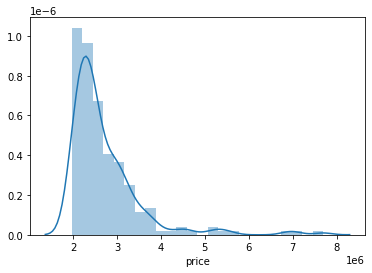

```python
sns.distplot(df['price'][df['price'] > df['price'].quantile(
    0.99)]);
```

this looks like a poisson distribution starting from 2.0e+6

```python
df['price'][df['price'] > df['price'].quantile(
    0.99)] = df['price'].quantile(0.99)
```

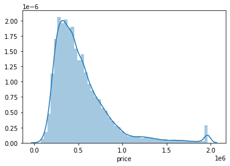

```python
sns.distplot(df['price'])
```

so there is a huge long tail to the right, i will max all the data to the 99th percentile the bump in the end signifies the long tail grouped together,

```python
pd.set_option('display.max_columns', df.shape[1])
df.describe()
```

|  | price | bedrooms | bathrooms | sqft_living | sqft_lot | floors | waterfront | view | condition | grade | sqft_above | sqft_basement | yr_built | yr_renovated | zipcode | lat | long | sqft_living15 | sqft_lot15 | year | month | day |
| --- | --- | --- | --- | --- | --- | --- | --- | --- | --- | --- | --- | --- | --- | --- | --- | --- | --- | --- | --- | --- | --- | --- |
| count | 2.161300e+04 | 21613.000000 | 21613.000000 | 21613.000000 | 2.161300e+04 | 21613.000000 | 21613.000000 | 21613.000000 | 21613.000000 | 21613.000000 | 21613.000000 | 21613.000000 | 21613.000000 | 21613.000000 | 21613.000000 | 21613.000000 | 21613.000000 | 21613.000000 | 21613.000000 | 21613.000000 | 21613.000000 | 21613.000000 |
| mean | 5.326364e+05 | 3.370842 | 2.114757 | 2079.899736 | 1.510697e+04 | 1.494309 | 0.007542 | 0.234303 | 3.409430 | 7.656873 | 1788.390691 | 291.509045 | 1971.005136 | 84.402258 | 98077.939805 | 47.560053 | -122.213896 | 1986.552492 | 12768.455652 | 2014.322954 | 6.574423 | 15.688197 |
| std | 3.177554e+05 | 0.930062 | 0.770163 | 918.440897 | 4.142051e+04 | 0.539989 | 0.086517 | 0.766318 | 0.650743 | 1.175459 | 828.090978 | 442.575043 | 29.373411 | 401.679240 | 53.505026 | 0.138564 | 0.140828 | 685.391304 | 27304.179631 | 0.467616 | 3.115308 | 8.635063 |
| min | 7.500000e+04 | 0.000000 | 0.000000 | 290.000000 | 5.200000e+02 | 1.000000 | 0.000000 | 0.000000 | 1.000000 | 1.000000 | 290.000000 | 0.000000 | 1900.000000 | 0.000000 | 98001.000000 | 47.155900 | -122.519000 | 399.000000 | 651.000000 | 2014.000000 | 1.000000 | 1.000000 |
| 25% | 3.219500e+05 | 3.000000 | 1.750000 | 1427.000000 | 5.040000e+03 | 1.000000 | 0.000000 | 0.000000 | 3.000000 | 7.000000 | 1190.000000 | 0.000000 | 1951.000000 | 0.000000 | 98033.000000 | 47.471000 | -122.328000 | 1490.000000 | 5100.000000 | 2014.000000 | 4.000000 | 8.000000 |
| 50% | 4.500000e+05 | 3.000000 | 2.250000 | 1910.000000 | 7.618000e+03 | 1.500000 | 0.000000 | 0.000000 | 3.000000 | 7.000000 | 1560.000000 | 0.000000 | 1975.000000 | 0.000000 | 98065.000000 | 47.571800 | -122.230000 | 1840.000000 | 7620.000000 | 2014.000000 | 6.000000 | 16.000000 |
| 75% | 6.450000e+05 | 4.000000 | 2.500000 | 2550.000000 | 1.068800e+04 | 2.000000 | 0.000000 | 0.000000 | 4.000000 | 8.000000 | 2210.000000 | 560.000000 | 1997.000000 | 0.000000 | 98118.000000 | 47.678000 | -122.125000 | 2360.000000 | 10083.000000 | 2015.000000 | 9.000000 | 23.000000 |
| max | 1.964400e+06 | 33.000000 | 8.000000 | 13540.000000 | 1.651359e+06 | 3.500000 | 1.000000 | 4.000000 | 5.000000 | 13.000000 | 9410.000000 | 4820.000000 | 2015.000000 | 2015.000000 | 98199.000000 | 47.777600 | -121.315000 | 6210.000000 | 871200.000000 | 2015.000000 | 12.000000 | 31.000000 |

**4. Fitting a simple linear model**

```python
X = df.drop('price', axis=1)
y = df['price']
```

```python
X_train, X_test, y_train, y_test = train_test_split(X, y, test_size=0.2)
model = LinearRegression()
model.fit(X_train, y_train)
predictions = model.predict(X_test)
r2 = r2_score(y_true=y_test, y_pred=predictions)
mae = mean_absolute_error(y_true=y_test, y_pred=predictions)
mse = mean_squared_error(y_true=y_test, y_pred=predictions)
```

```python
print(f'r2: {r2}\nmean abs error: {mae}\nmean sq error: {mse}')
```

```
r2: 0.736722367336007
mean abs error: 111619.00923945577
mean sq error: 25766458025.644627
```

let's visualize how well the model performed.

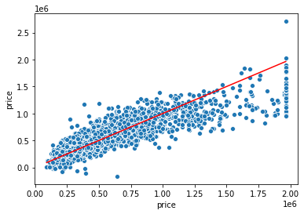

```python
sns.scatterplot(y_test,predictions)
sns.lineplot(y_test,y_test, color='red');
```

As expected, you can see that due to scaling the model varies greatly at the 2M mark.  
So, that is a pretty good score at first, but let's see if that persists: do cross validation

```python
scorers = ['r2', 'neg_mean_absolute_error', 'neg_mean_squared_error']
x_df = pd.DataFrame(cross_validate(model, X, y, cv=KFold(5),scoring=scorers, return_estimator=False))
x_df
```

|  | fit_time | score_time | test_r2 | test_neg_mean_absolute_error | test_neg_mean_squared_error |
| --- | --- | --- | --- | --- | --- |
| 0 | 0.009530 | 0.002035 | 0.744651 | -113960.525414 | -2.590972e+10 |
| 1 | 0.008865 | 0.001584 | 0.734295 | -112677.820797 | -2.568641e+10 |
| 2 | 0.008272 | 0.002547 | 0.735099 | -110158.972863 | -2.443602e+10 |
| 3 | 0.007739 | 0.002357 | 0.742312 | -114324.950029 | -2.727358e+10 |
| 4 | 0.008000 | 0.002029 | 0.716850 | -116571.449491 | -3.046212e+10 |

The model does fairly consistently, around r^2 = 0.73

**5. Creating new variables and testing for significance**

Let's see if there is some additional feature engineering to be done to improve model performance

```python
df['renovated'] = df['yr_renovated']>0
df['has_basement'] = df['sqft_basement']>0
```

```python
for col in ['has_basement', 'renovated']:
    print('\n','*'*len(col),'\n',col,'\n','*'*len(col))
    print(df[col].value_counts(dropna = False))
```

```
 ************
 has_basement
 ************
False    13126
True      8487
Name: has_basement, dtype: int64

 *********
 renovated
 *********
False    20699
True       914
Name: renovated, dtype: int64
```

The column "renovated" appears to be very imbalanced, however, "has_basement" can appear promising

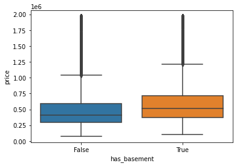

```python
target = 'price'
sns.boxplot(data=df, x='has_basement', y=target)
```

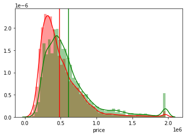

```python
sns.distplot(df[df['has_basement'] == False][target], color='r')
sns.distplot(df[df['has_basement'] == True][target], color='g')
plt.axvline(df[df['has_basement'] == False][target].mean(), color = 'r')
plt.axvline(df[df['has_basement'] == True][target].mean(), color = 'g');
```

The vertical lines signify the means of the prices of the houses with and without basements respectively

By looking at the data, it appears that this is not significant, however, let's conduct a t-test to see if that is actually the case

```python
stats.ttest_ind(df[df['has_basement'] == False][target],
                df[df['has_basement'] == True][target])
```

```
Ttest_indResult(statistic=-28.297701395963394, pvalue=5.2333564562191034e-173)
```

As the p value significantly approaches 0 and the t-statistic is on the left end of the t distribution, it is safe to assume that there is indeed significant difference between the means of the prices of houses with and without basements.

**6. Correlation analysis and a note on multicollinearity**

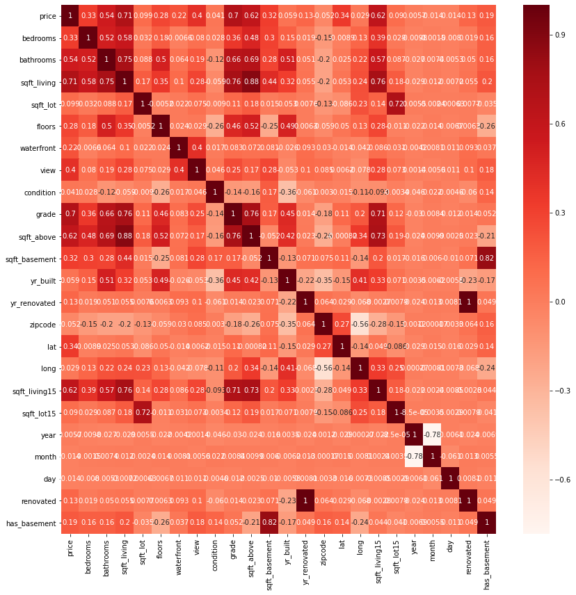

```python
plt.subplots(figsize=(14,14))
sns.heatmap(df.corr(), annot = True, cmap="Reds");
```

```python
correldf = df.corr()
correldf.iloc[0,:].sort_values(ascending = False)[1:]
feature_list = correldf.iloc[0, :].sort_values(ascending=False)[1:]

feature_list
```

```
sqft_living      0.708827
grade            0.700003
sqft_living15    0.619013
sqft_above       0.615693
bathrooms        0.536969
view             0.396055
lat              0.344091
bedrooms         0.325440
sqft_basement    0.318964
floors           0.278854
waterfront       0.222431
has_basement     0.189022
yr_renovated     0.128872
renovated        0.128502
sqft_lot         0.098666
sqft_lot15       0.089649
yr_built         0.058593
condition        0.040594
long             0.029049
year             0.005729
day             -0.014064
month           -0.014356
zipcode         -0.052320
Name: price, dtype: float64
```

*Multicollinearity* occurs when in regression one or more variables are not just correlated with the target variables, but with themselves as well. The problem with this is that adding multiple features which are good predictors of each other does not add substantial amount of information the the analysis. However, in our case this should not affect our analysis. According to wikipedia [m]ulticollinearity does not reduce the predictive power or reliability of the model as a whole, at least within the sample data set; it only affects calculations regarding individual predictors. That is, a multivariate regression model with collinear predictors can indicate how well the entire bundle of predictors predicts the outcome variable, but it may not give valid results about any individual predictor, or about which predictors are redundant with respect to others.

**7. Comparing different model outputs**

```python
X = df.drop('price', axis=1)
X1 = df[['sqft_living',
       'grade',
       'sqft_living15',
       'sqft_above',
       'bathrooms',
       'view',
       'lat',
       'bedrooms',
       'sqft_basement',
       'floors',
       'waterfront',
       'has_basement',
       'yr_renovated',
       'renovated']]
y = df['price']
```

```python
models = {
    'linear_regression': LinearRegression(),
    'ridge': Ridge(),
    'random_forest': RandomForestRegressor()
}
```

```python
def compare_models(models,X,y,no_iterations = 3):
    model_scores = pd.DataFrame(columns=[0, 1, 2])
    for i in range(no_iterations):
        model_scores = model_scores.append(pd.DataFrame.from_dict({0:['*'],1:[f'iteration {i+1}'],2:['*']}))
        for name, model in models.items():
            X_train, X_test, y_train, y_test = train_test_split(X,y, test_size = 0.2)
            print(f'fitting model: {name} on iteration {i}')
            model.fit(X_train, y_train)
            predictions = model.predict(X_test)
            r2 = r2_score(y_true=y_test , y_pred=predictions)
            mae = mean_absolute_error(y_true=y_test, y_pred=predictions)
            mse = mean_squared_error(y_true=y_test, y_pred=predictions)
            df1 = pd.DataFrame({name: [r2, mae, mse]}).transpose()
            model_scores = model_scores.append(df1)
    model_scores.rename(
        columns={0: 'r2', 1: 'mean_absolute_error', 2: 'mean_squared_error'}, inplace=True)
    return model_scores
```

```python
a = compare_models(models,X,y)

a
```

```
fitting model: linear_regression on iteration 0
fitting model: ridge on iteration 0
fitting model: random_forest on iteration 0
fitting model: linear_regression on iteration 1
fitting model: ridge on iteration 1
fitting model: random_forest on iteration 1
fitting model: linear_regression on iteration 2
fitting model: ridge on iteration 2
fitting model: random_forest on iteration 2
```

|  | r2 | mean_absolute_error | mean_squared_error |
| --- | --- | --- | --- |
| 0 | * | iteration 1 | * |
| linear_regression | 0.733576 | 113460 | 2.74332e+10 |
| ridge | 0.72826 | 114521 | 2.75164e+10 |
| random_forest | 0.878098 | 68112.5 | 1.26203e+10 |
| 0 | * | iteration 2 | * |
| linear_regression | 0.747766 | 112191 | 2.57363e+10 |
| ridge | 0.74945 | 112298 | 2.62447e+10 |
| random_forest | 0.874059 | 66077.2 | 1.24178e+10 |
| 0 | * | iteration 3 | * |
| linear_regression | 0.73776 | 111635 | 2.56876e+10 |
| ridge | 0.741246 | 112090 | 2.58955e+10 |
| random_forest | 0.887557 | 65815.7 | 1.17598e+10 |

```python
b = compare_models(models,X1,y)

b
```

```
fitting model: linear_regression on iteration 0
fitting model: ridge on iteration 0
fitting model: random_forest on iteration 0
fitting model: linear_regression on iteration 1
fitting model: ridge on iteration 1
fitting model: random_forest on iteration 1
fitting model: linear_regression on iteration 2
fitting model: ridge on iteration 2
fitting model: random_forest on iteration 2
```

|  | r2 | mean_absolute_error | mean_squared_error |
| --- | --- | --- | --- |
| 0 | * | iteration 1 | * |
| linear_regression | 0.697278 | 120638 | 2.95478e+10 |
| ridge | 0.702855 | 119652 | 3.03566e+10 |
| random_forest | 0.838817 | 81817.4 | 1.67548e+10 |
| 0 | * | iteration 2 | * |
| linear_regression | 0.706992 | 118441 | 2.88227e+10 |
| ridge | 0.706526 | 118872 | 2.91476e+10 |
| random_forest | 0.827332 | 82288.9 | 1.70079e+10 |
| 0 | * | iteration 3 | * |
| linear_regression | 0.701106 | 121448 | 3.06219e+10 |
| ridge | 0.713335 | 118419 | 2.89708e+10 |
| random_forest | 0.843032 | 79948.6 | 1.63131e+10 |

so our models are doing well, with random forest coming out on top  
let's verify using the built in cross-validate method

```python
scorers = ['r2', 'neg_mean_absolute_error', 'neg_mean_squared_error']
model = RandomForestRegressor()
```

```python
x_df = pd.DataFrame(cross_validate(model, X, y, cv=KFold(5),
                                   scoring=scorers, return_estimator=False))
x_df
```

|  | fit_time | score_time | test_r2 | test_neg_mean_absolute_error | test_neg_mean_squared_error |
| --- | --- | --- | --- | --- | --- |
| 0 | 12.325695 | 0.103519 | 0.891597 | -65303.659367 | -1.099945e+10 |
| 1 | 12.392575 | 0.096137 | 0.893124 | -63935.376691 | -1.033201e+10 |
| 2 | 12.882003 | 0.095150 | 0.877579 | -65682.735944 | -1.129279e+10 |
| 3 | 12.656000 | 0.101866 | 0.889737 | -66296.685427 | -1.167015e+10 |
| 4 | 12.576998 | 0.095539 | 0.885085 | -68328.215676 | -1.236292e+10 |

```python
X_train, X_test, y_train, y_test = train_test_split(X, y, test_size=0.2)

model.fit(X_train, y_train)
predictions = model.predict(X_test)
r2 = r2_score(y_true=y_test, y_pred=predictions)
mae = mean_absolute_error(y_true=y_test, y_pred=predictions)
mse = mean_squared_error(y_true=y_test, y_pred=predictions)

print(f'r2: {r2}\nmean abs error: {mae}\nmean sq error: {mse}')
```

```
r2: 0.8938507277847811
mean abs error: 63670.81788804076
mean sq error: 10390169017.137825
```

Let's visualize how well the model performed.

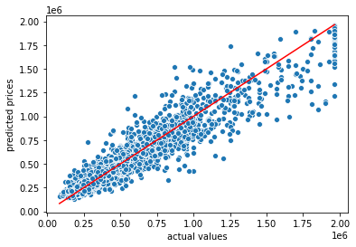

```python
sns.lineplot(x = y_test, y = y_test, color='red')
scatter = sns.scatterplot(x = y_test, y = predictions)
scatter.set(xlabel='actual values', ylabel='predicted prices');
```